# DSAN 6500: Week 02 - Classical Computer Vision

- Show All Code
- Hide All Code

Author

Prof. Ben Houghton

Published

January 20, 2026

# Classical Computer Vision

- Week 02
- Noise, filtering, edges, morphology

## Agenda

- Image noise
- Filters, convolutions, and correlations
- Gaussian smoothing
- Median filtering
- Image derivatives
- Edge detection
- Morphology

### Reminders

- Turn in Lab 1
- Today we will have Quiz 1
- Next week Lab 2 and Quiz 2

## Classic CV images (skimage.data)

We will use classic reference images so results are comparable to the CV literature.

- camera (cameraman): strong edges and texture
- coins: clear object boundaries for edges and morphology
- page: text for sharpening vs noise
- astronaut: color photo for blur/sharpen tradeoffs
- horse: binary mask for morphology
- checkerboard: for edge detection

Note: the historic “Lena” image is not shipped in scikit-image due to licensing.

```python
import numpy as np
import matplotlib.pyplot as plt
import cv2
from skimage import data

plt.rcParams["figure.dpi"] = 120


def show_gray(ax, img, title):
    ax.imshow(img, cmap="gray", vmin=0, vmax=255)
    ax.set_title(title)
    ax.axis("off")


def show_rgb(ax, img, title):
    ax.imshow(img)
    ax.set_title(title)
    ax.axis("off")


def to_uint8(img):
    if img.dtype == np.uint8:
        return img
    img = np.clip(img, 0, 1)
    return (img * 255).astype(np.uint8)


# Load classic images
camera = data.camera()  # grayscale uint8
coins = data.coins()    # grayscale uint8
page = data.page()      # grayscale uint8
astronaut = data.astronaut()  # RGB uint8
horse = data.horse()    # boolean mask
checkerboard = data.checkerboard() # grayscale uint8

horse_u8 = (horse.astype(np.uint8) * 255)

print("Loaded classic images:")
print("camera", camera.shape, camera.dtype)
print("coins", coins.shape, coins.dtype)
print("page", page.shape, page.dtype)
print("astronaut", astronaut.shape, astronaut.dtype)
print("horse", horse.shape, horse.dtype)
print("checkerboard", checkerboard.shape, checkerboard.dtype)
```

```
Loaded classic images:
camera (512, 512) uint8
coins (303, 384) uint8
page (191, 384) uint8
astronaut (512, 512, 3) uint8
horse (328, 400) bool
checkerboard (200, 200) uint8
```

If `skimage` is not installed, run:

```
pip install scikit-image
```

We will use `skimage.data` for classic CV images.

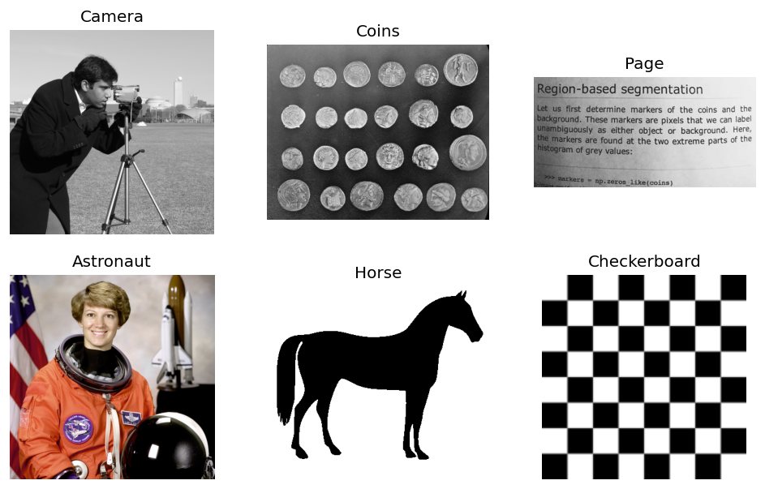

```python
# Plot the classic images
images = [camera, coins, page, astronaut, horse, checkerboard]
titles = ["camera", "coins", "page", "astronaut", "horse", "checkerboard"]

fig, axes = plt.subplots(2, 3, figsize=(10, 6))

for i, (img, title) in enumerate(zip(images, titles)):
    row = i // 3
    col = i % 3
    ax = axes[row, col]
    ax.imshow(img, cmap="gray")
    ax.set_title(title.capitalize())
    ax.axis("off")
```

# Image formation and noise

- Sensors measure light -> discrete pixels (sampling + quantization)
- Optics introduce blur (motion, defocus, diffraction)
- Measurements are noisy (photon statistics, sensor electronics, compression)
- Noise changes edge strength and texture stability
- Filtering trades noise reduction for loss of fine detail

## What is noise?

- Unwanted random variation in measurements
- Makes edges and textures unstable
- Different noise types require different filters

[figure not shown]

```python
# Demo: add Gaussian and salt-and-pepper noise to a classic image
img = camera.copy().astype(np.float32)

# Gaussian noise
sigma = 20.0
noise = np.random.normal(0, sigma, img.shape)
img_gauss = np.clip(img + noise, 0, 255).astype(np.uint8)

# Salt-and-pepper noise
p = 0.02
salt_pepper = img.copy()
mask = np.random.rand(*img.shape)
salt_pepper[mask < p / 2] = 0
salt_pepper[(mask >= p / 2) & (mask < p)] = 255
salt_pepper = salt_pepper.astype(np.uint8)

fig, axes = plt.subplots(1, 3, figsize=(12, 4))
show_gray(axes[0], camera, "Original (camera)")
show_gray(axes[1], img_gauss, "Gaussian noise (sigma=20)")
show_gray(axes[2], salt_pepper, "Salt-and-pepper (p=0.02)")
plt.tight_layout()
plt.show()
```

# Image Filters and Convolutions

- A filter combines nearby pixels to produce a new pixel
- Most filters are a **weighted sum** with a small kernel (often implemented as correlation, not flipped convolution)
- Some filters are **nonlinear** and not convolution/correlation (e.g., median filter, bilateral filter)
- Filtering can smooth, detect edges, or enhance detail

## Convolution & Correlation

A kernel or filter slides over an image and computes a weighted sum of the pixel values in the neighborhood. This calculation is placed in the output image at the location of the center of the kernel.

$$(I * K)[x,y] = \sum_i \sum_j I[x-i, y-j] \; K[i,j]$$

- Kernel size is usually odd (3x3, 5x5)
- Boundary handling changes results near edges

**Important**: the kernel is flipped in the convolution equation.

- The kernel is not flipped in the correlation equation.
- In practice, many libraries use correlation but still call it “convolution”

$$(I \star K)[x,y] = \sum_i \sum_j I[x+i, y+j] \; K[i,j]$$

## Convolution calculation 1

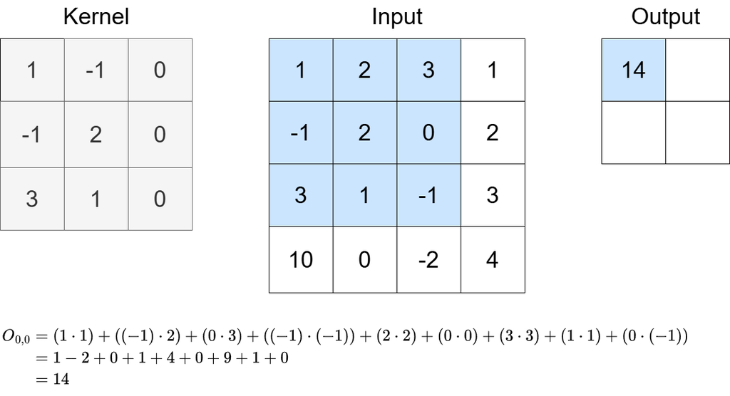

## Convolution calculation 2

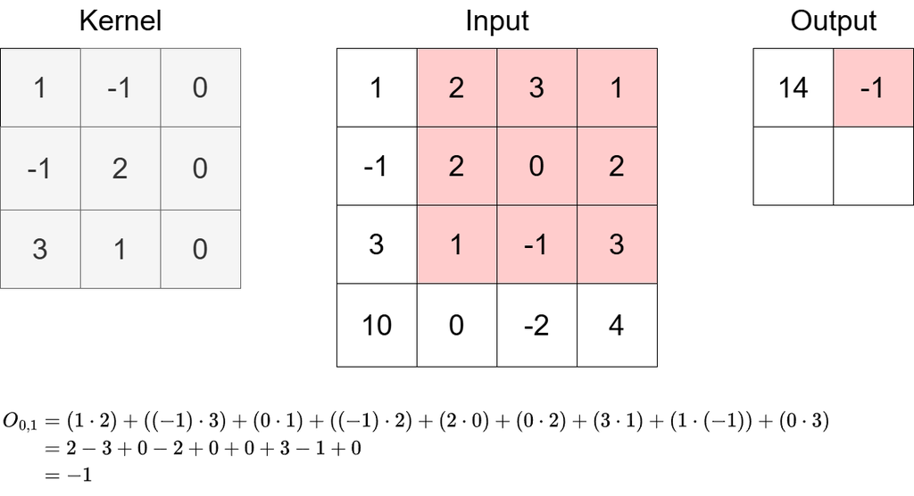

## Convolution calculation 3

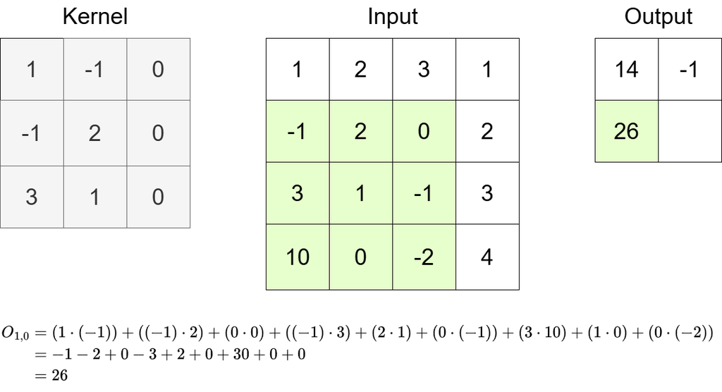

## Convolution calculation 4

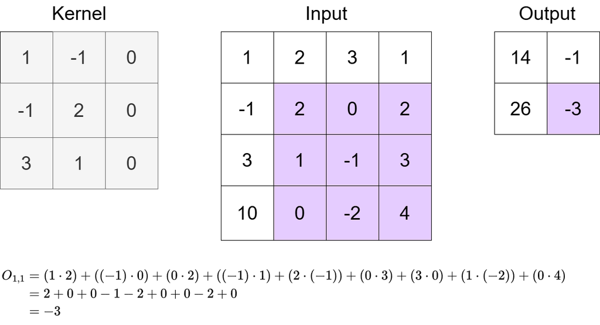

## Convolution calculation final

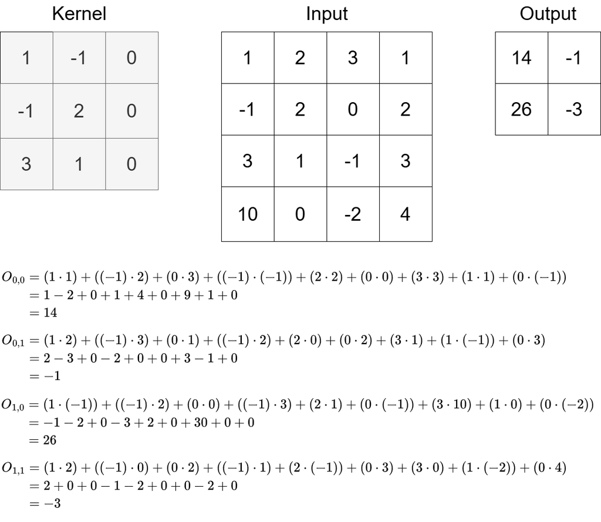

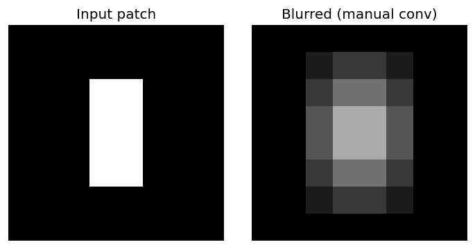

```python
# Demo: manual 3x3 convolution on a small patch
patch = np.array([
    [0, 0, 0, 0, 0, 0, 0, 0],
    [0, 0, 0, 0, 0, 0, 0, 0],
    [0, 0, 0, 255, 255, 0, 0, 0],
    [0, 0, 0, 255, 255, 0, 0, 0],
    [0, 0, 0, 255, 255, 0, 0, 0],
    [0, 0, 0, 255, 255, 0, 0, 0],
    [0, 0, 0, 0, 0, 0, 0, 0],
    [0, 0, 0, 0, 0, 0, 0, 0],
], dtype=np.float32)

kernel = np.array([
    [1, 1, 1],
    [1, 1, 1],
    [1, 1, 1],
], dtype=np.float32) / 9.0

pad = 1
padded = np.pad(patch, pad, mode="edge")
output = np.zeros_like(patch)

for i in range(patch.shape[0]):
    for j in range(patch.shape[1]):
        region = padded[i : i + 3, j : j + 3]
        output[i, j] = np.sum(region * kernel)

fig, axes = plt.subplots(1, 2, figsize=(6, 3))
show_gray(axes[0], patch, "Input patch")
show_gray(axes[1], output, "Blurred (manual conv)")
plt.tight_layout()
plt.show()
```

## Padding

- Padding is a common operation in image processing. It is used to handle the edges of an image when a kernel is applied.
- Allows for output to be the same shape as the input.

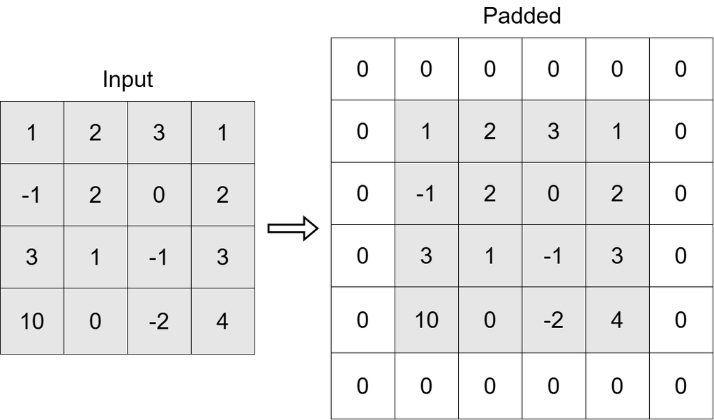

## Padding options

There are several options in [OpenCV](https://docs.opencv.org/4.x/d3/df2/tutorial_py_basic_ops.html) for padding when performing convolutions.

- `cv.BORDER_CONSTANT` - Adds a constant colored border. The value should be given as next argument.
- `cv.BORDER_REFLECT` - Border will be mirror reflection of the border elements, like this : fedcba|abcdefgh|hgfedcb
- `cv.BORDER_REFLECT_101` or `cv.BORDER_DEFAULT` - Same as above, but with a slight change, like this : gfedcb|abcdefgh|gfedcba
- `cv.BORDER_REPLICATE` - Last element is replicated throughout, like this: aaaaaa|abcdefgh|hhhhhhh
- `cv.BORDER_WRAP` - Can’t explain, it will look like this : cdefgh|abcdefgh|abcdefg

You will find similar options in [PyTorch](https://docs.pytorch.org/docs/stable/generated/torch.nn.Conv2d.html) when using `Conv2d` layers.

## OpenCV filtering

- cv2.filter2D: generic convolution
- cv2.GaussianBlur: Gaussian smoothing
- cv2.medianBlur: median filtering
- cv2.Sobel, cv2.Laplacian, cv2.Canny: edge detectors

Pitfalls: BGR vs RGB, dtype scaling, border handling.

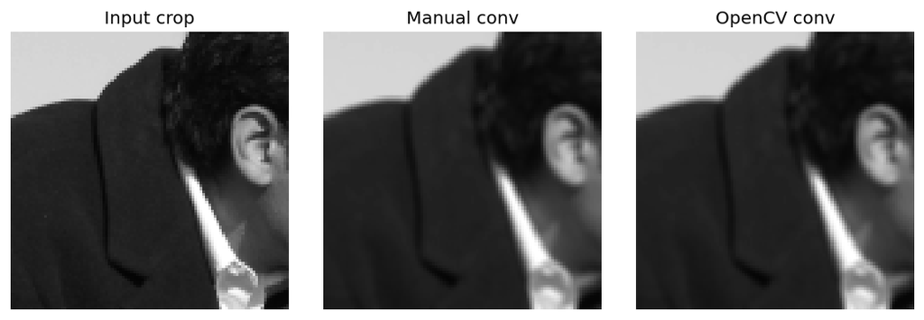

```python
# Demo: OpenCV vs manual convolution on a classic image
kernel = np.ones((3, 3), dtype=np.float32) / 9.0

manual = cv2.filter2D(camera, -1, kernel, borderType=cv2.BORDER_REFLECT)

# Manual loop on a small crop (for speed)
crop = camera[100:200, 100:200].astype(np.float32)
padded = np.pad(crop, 1, mode="edge")
manual_crop = np.zeros_like(crop)
for i in range(crop.shape[0]):
    for j in range(crop.shape[1]):
        manual_crop[i, j] = np.sum(padded[i : i + 3, j : j + 3] * kernel)

cv_crop = cv2.filter2D(crop, -1, kernel, borderType=cv2.BORDER_REFLECT)

fig, axes = plt.subplots(1, 3, figsize=(9, 3))
show_gray(axes[0], crop, "Input crop")
show_gray(axes[1], manual_crop, "Manual conv")
show_gray(axes[2], cv_crop, "OpenCV conv")
plt.tight_layout()
plt.show()
```

# Gaussian blur and smoothing

- Smooths high-frequency noise
- Often used before edge detection or downsampling
- Tradeoff: noise removed and detail lost

## Gaussian Kernel

- Kernel size and sigma control how much smoothing happens
- Larger sigma -> stronger blur

$$G(x,y) \propto \exp\left(-\frac{x^2+y^2}{2\sigma^2}\right)$$

**Normalized Gaussian Kernel**

$$G(x,y) = \frac{1}{2\pi\sigma^2} \exp\left(-\frac{x^2+y^2}{2\sigma^2}\right)$$

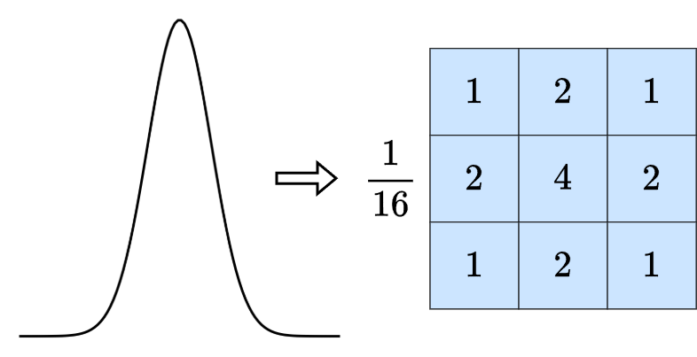

### 7x7 Gaussian kernels

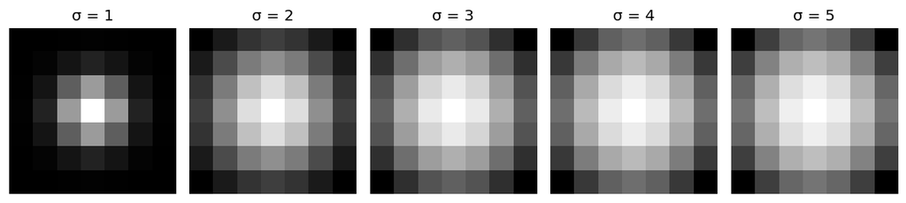

```python
# Gaussian Kernel
def gaussian_function(x, y, sigma, normalize=True):
    if normalize:
        return np.exp(-(x**2 + y**2) / (2 * sigma**2)) / (2 * np.pi * sigma**2)
    else:
        return np.exp(-(x**2 + y**2) / (2 * sigma**2))

size = 7
x = np.arange(-(size-1)//2, (size-1)//2+1, 1)
y = np.arange(-(size-1)//2, (size-1)//2+1, 1)
X, Y = np.meshgrid(x, y)

kernel = gaussian_function(X, Y, 1)

sigmas = [1, 2, 3, 4, 5]

fig, axes = plt.subplots(1, len(sigmas), figsize=(10, 10))
for i, sigma in enumerate(sigmas):
    kernel = gaussian_function(X, Y, sigma)
    axes[i].imshow(kernel, cmap='gray')
    axes[i].axis('off')
    axes[i].set_title(f'\u03c3 = {sigma}')
plt.tight_layout()
plt.show()
```

### Gaussian smoothing

[figure not shown]

```python
# Demo: Gaussian smoothing on a noisy image (camera)
noisy = img_gauss

blur_1 = cv2.GaussianBlur(noisy, (3, 3), 0)
blur_2 = cv2.GaussianBlur(noisy, (7, 7), 0)
blur_3 = cv2.GaussianBlur(noisy, (11, 11), 0)

fig, axes = plt.subplots(1, 4, figsize=(12, 4))
show_gray(axes[0], noisy, "Noisy")
show_gray(axes[1], blur_1, "Gaussian 3x3")
show_gray(axes[2], blur_2, "Gaussian 7x7")
show_gray(axes[3], blur_3, "Gaussian 11x11")
plt.tight_layout()
plt.show()
```

[figure not shown]

```python
# Demo: Gaussian blur on a color image (astronaut)
astronaut_blur = cv2.GaussianBlur(astronaut, (7, 7), 0)

fig, axes = plt.subplots(1, 2, figsize=(8, 4))
show_rgb(axes[0], astronaut, "Original (astronaut)")
show_rgb(axes[1], astronaut_blur, "Gaussian blur 7x7")
plt.tight_layout()
plt.show()
```

## Gaussian tuning pitfalls

- Sigma too small: noise remains
- Sigma too large: edges and texture vanish
- Boundary handling can create artifacts near the image border

# Median filtering

- Nonlinear filter: replaces each pixel with the median of its neighborhood
- Excellent for salt-and-pepper noise
- Preserves edges better than Gaussian for impulse noise
- Sort the neighborhood values -> take the middle
- Robust to outliers (impulse noise)

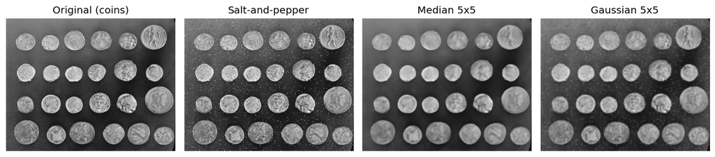

```python
# Demo: median vs Gaussian on salt-and-pepper noise (coins)
coins_sp = coins.copy()
mask = np.random.rand(*coins.shape)
coins_sp[mask < p / 2] = 0
coins_sp[(mask >= p / 2) & (mask < p)] = 255

coins_med = cv2.medianBlur(coins_sp, 5)
coins_gauss = cv2.GaussianBlur(coins_sp, (5, 5), 0)

fig, axes = plt.subplots(1, 4, figsize=(12, 4))
show_gray(axes[0], coins, "Original (coins)")
show_gray(axes[1], coins_sp, "Salt-and-pepper")
show_gray(axes[2], coins_med, "Median 5x5")
show_gray(axes[3], coins_gauss, "Gaussian 5x5")
plt.tight_layout()
plt.show()
```

## Median tradeoffs

- Kernel size controls smoothing strength
- Too large -> cartooning, texture loss
- Often slower than Gaussian in practice

# Image derivatives

- An image can be modeled as a continuous function where intensity varies over spatial coordinates.
- Derivatives measure **how intensity changes in space**.

$$I(x, y)$$

## First order derivatives

$$I_x = \frac{\partial I}{\partial x}, \quad I_y = \frac{\partial I}{\partial y}$$

**Definition (1D intuition)**
$$\frac{\partial I}{\partial x} = \lim_{h\to 0} \frac{I(x+h, y) - I(x-h, y)}{2h}$$

On a pixel grid, the spacing is 1, so the discrete approximation becomes:
$$\frac{\partial I}{\partial x} \approx \frac{I(x+1, y) - I(x-1, y)}{2}$$

**Sobel is just a smoothed (Gaussian) finite difference**: it computes this derivative while averaging in the perpendicular direction to reduce noise.

- Large magnitude → **strong intensity change**
- Small magnitude → **flat region**
- Direction of maximum change given by the **gradient vector**

**Discrete Approximation (Filters)**

Since images are discrete, derivatives are approximated using convolution:

**Simple finite differences**
$$[-1, 0, 1]$$

**Sobel filters (most common)**

$$G_x =
\begin{bmatrix}
-1 & 0 & 1 \\
-2 & 0 & 2 \\
-1 & 0 & 1
\end{bmatrix}
\quad
G_y =
\begin{bmatrix}
-1 & -2 & -1 \\
0 & 0 & 0 \\
1 & 2 & 1
\end{bmatrix}$$

**What First Derivatives Detect**

- **Edges**
- **Texture direction**
- **Motion cues**
- **Keypoints (via gradient structure)**

They respond strongly at **intensity discontinuities**.

## Second-Order Image Derivatives

Second derivatives measure **how the gradient itself changes**.

**Second Partial Derivatives**

$$I_{xx} = \frac{\partial^2 I}{\partial x^2}, \quad
I_{yy} = \frac{\partial^2 I}{\partial y^2}, \quad
I_{xy} = \frac{\partial^2 I}{\partial x \partial y}$$

**Definition (1D intuition)**
$$\frac{\partial^2 I}{\partial x^2} = \lim_{h\to 0} \frac{I(x+h, y) - 2I(x, y) + I(x-h, y)}{h^2}$$

On a pixel grid (spacing 1), this becomes the discrete second difference:
$$\frac{\partial^2 I}{\partial x^2} \approx I(x+1, y) - 2I(x, y) + I(x-1, y)$$

The 2D **Laplacian** sums second differences in x and y, which yields the classic Laplacian kernels below.

They capture **curvature** rather than slope.

**The Laplacian**

The most common second-order operator is the **Laplacian**:

$$\nabla^2 I = I_{xx} + I_{yy}$$

On a grid, this becomes a sum of second differences in x and y. Using only the 4-connected neighbors yields the 5-point stencil:
$$\begin{bmatrix}
0 & 1 & 0 \\
1 & -4 & 1 \\
0 & 1 & 0
\end{bmatrix}$$

Including the **8-connected** neighbors gives the 9-point stencil, which more closely approximates an isotropic Laplacian:
$$\begin{bmatrix}
1 & 1 & 1 \\
1 & -8 & 1 \\
1 & 1 & 1
\end{bmatrix}$$

**Interpretation**

- Zero-crossings → **edges**
- Positive values → **local minima**
- Negative values → **local maxima**

Second derivatives do **not** provide orientation directly.

## Derivatives Recap

| Aspect | First Derivative | Second Derivative |
| --- | --- | --- |
| Measures | Slope | Curvature |
| Responds to | Intensity change | Change of change |
| Edge detection | Yes (direct) | Yes (via zero-crossings) |
| Orientation | Yes | No |
| Noise sensitivity | High | Very high |

- **First derivatives find where intensity changes**
- **Second derivatives find where that change peaks or flips**
- Gradients → edges
- Laplacians / Hessians → blobs, corners, curvature

# Image thresholding

- Turns grayscale into a binary mask (foreground vs background)
- Useful for quick segmentation, counting, or cleanup before morphology
- Global thresholds work when lighting is uniform; adaptive/OTSU handle uneven illumination
- Sensitive to noise, so light smoothing is common
- Used as pre-processing or post-processing step in many CV pipelines

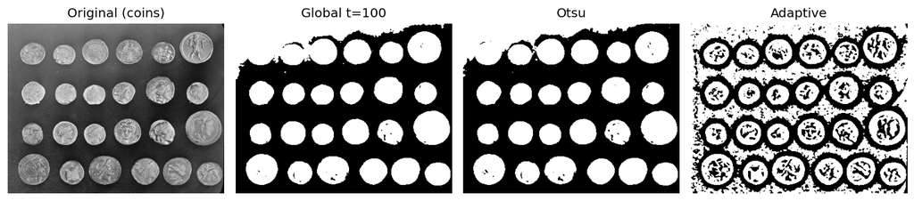

```python
# Demo: thresholding on coins (global vs Otsu vs adaptive)
coins_blur = cv2.GaussianBlur(coins, (5, 5), 0)

_, th_global = cv2.threshold(coins_blur, 100, 255, cv2.THRESH_BINARY)
_, th_otsu = cv2.threshold(coins_blur, 0, 255, cv2.THRESH_BINARY + cv2.THRESH_OTSU)
th_adapt = cv2.adaptiveThreshold(
    coins_blur, 255, cv2.ADAPTIVE_THRESH_GAUSSIAN_C, cv2.THRESH_BINARY, 31, 2
)

fig, axes = plt.subplots(1, 4, figsize=(12, 3))
show_gray(axes[0], coins, "Original (coins)")
show_gray(axes[1], th_global, "Global t=100")
show_gray(axes[2], th_otsu, "Otsu")
show_gray(axes[3], th_adapt, "Adaptive")
plt.tight_layout()
plt.show()
```

# Edge detection

- Edges are strong intensity changes (gradients)
- Common pipeline: grayscale -> optional blur -> edges
- Used for segmentation hints, alignment, QA, and feature extraction

**Some edge detection operations**

- Sobel
- Laplacian
- Canny

## Sobel

- Approximates the image gradient with small 3x3 filters in x and y
- Strong response where intensity changes rapidly (edges)
- Combine x and y responses into a gradient magnitude image
- Often preceded by slight smoothing to reduce noise-driven edges

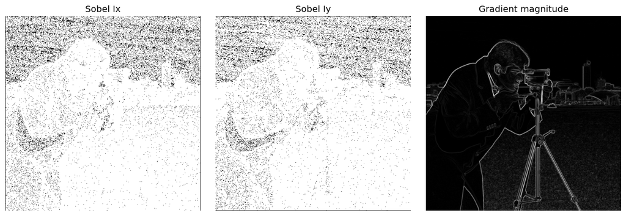

```python
# Demo: Sobel edges on camera
sx = cv2.Sobel(camera, cv2.CV_32F, 1, 0, ksize=3)
sy = cv2.Sobel(camera, cv2.CV_32F, 0, 1, ksize=3)
mag = np.sqrt(sx**2 + sy**2)
mag = np.clip(mag / mag.max() * 255, 0, 255).astype(np.uint8)

fig, axes = plt.subplots(1, 3, figsize=(12, 4))
show_gray(axes[0], to_uint8(np.abs(sx)), "Sobel Ix")
show_gray(axes[1], to_uint8(np.abs(sy)), "Sobel Iy")
show_gray(axes[2], mag, "Gradient magnitude")
plt.tight_layout()
plt.show()
```

## Laplacian

- Highlights rapid changes but is noise sensitive
- Often paired with smoothing (Laplacian of Gaussian)
- Useful for edge emphasis and detecting fine detail (thin lines, small features)
- Can be used in sharpening (subtract Laplacian from original)
- Good for blob/spot detection when searching for small, bright or dark structures

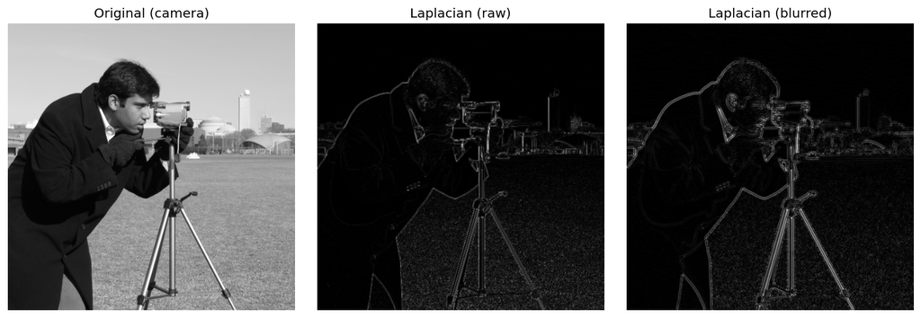

```python
# Demo: Laplacian on raw vs blurred
lap_raw = cv2.Laplacian(camera, cv2.CV_32F, ksize=3)
blurred = cv2.GaussianBlur(camera, (5, 5), 0)
# Smoothing removes high‑frequency noise so the Laplacian highlights meaningful
# edges instead of speckle
lap_blur = cv2.Laplacian(blurred, cv2.CV_32F, ksize=3)

lap_raw_u8 = to_uint8(np.abs(lap_raw) / np.max(np.abs(lap_raw)))
lap_blur_u8 = to_uint8(np.abs(lap_blur) / np.max(np.abs(lap_blur)))

fig, axes = plt.subplots(1, 3, figsize=(12, 4))
show_gray(axes[0], camera, "Original (camera)")
show_gray(axes[1], lap_raw_u8, "Laplacian (raw)")
show_gray(axes[2], lap_blur_u8, "Laplacian (blurred)")
plt.tight_layout()
plt.show()
```

## Canny edge detection (pipeline)

1. Gaussian blur
2. Gradient magnitude
3. Non-max suppression
   - Keep only local maxima along the gradient direction
   - Thins wide edge responses to single-pixel ridges
4. Hysteresis thresholding

Key parameters: threshold1, threshold2, and blur strength.

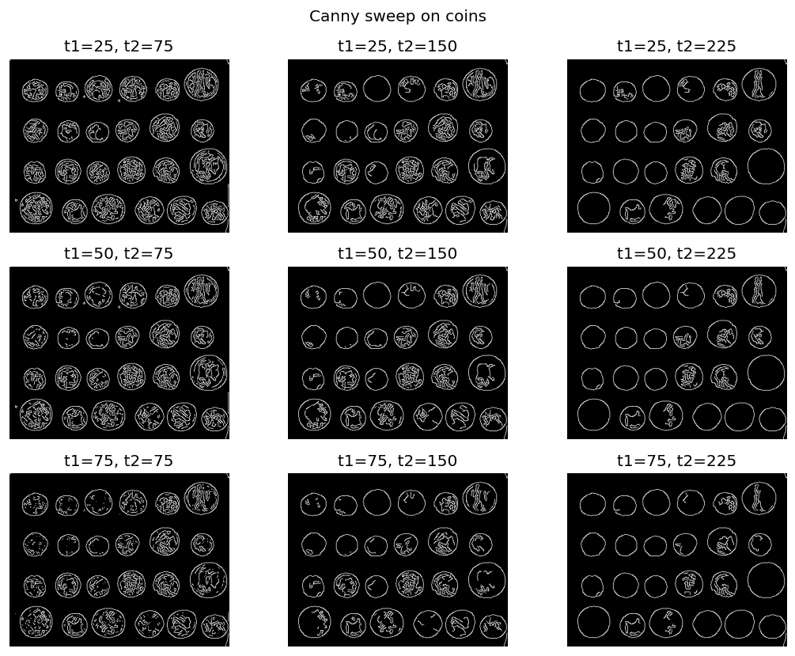

```python
# Demo: Canny parameter sweep (coins)
pre = cv2.GaussianBlur(coins, (5, 5), 0)

thresholds1 = [25, 50, 75]
thresholds2 = [75, 150, 225]

fig, axes = plt.subplots(len(thresholds1), len(thresholds2), figsize=(9, 7))
for i, t1 in enumerate(thresholds1):
    for j, t2 in enumerate(thresholds2):
        edges = cv2.Canny(pre, t1, t2)
        ax = axes[i, j]
        show_gray(ax, edges, f"t1={t1}, t2={t2}")

plt.suptitle("Canny sweep on coins")
plt.tight_layout()
plt.show()
```

# Sharpening and unsharp masking

- Increases high-frequency detail (edges pop)
- Common in photography pipelines
- Can amplify noise if overdone

## Unsharp masking (math)

- Blur: $B = G_\sigma(I)$
- Mask: $M = I - B$
- Sharpen: $I' = I + \alpha M$

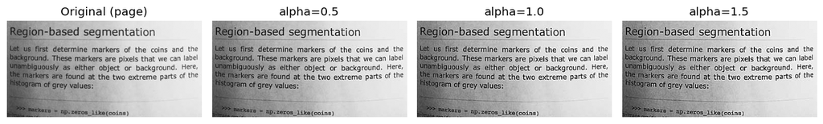

```python
# Demo: unsharp masking (page)
blur = cv2.GaussianBlur(page, (5, 5), 0)

alphas = [0.5, 1.0, 1.5]

fig, axes = plt.subplots(1, len(alphas) + 1, figsize=(12, 4))
show_gray(axes[0], page, "Original (page)")

for i, a in enumerate(alphas, start=1):
    sharp = cv2.addWeighted(page, 1 + a, blur, -a, 0)
    show_gray(axes[i], sharp, f"alpha={a}")

plt.tight_layout()
plt.show()
```

## Sharpening pitfalls

- Amplifies noise, especially in dark regions
- Can create halos or ringing around edges
- Best used after denoising

# Morphological operations

- Operate on binary images using a structuring element
- Useful for cleaning up masks and edges
- Common in segmentation post-processing

## Erosion, dilation, opening, closing

- Erosion shrinks foreground
- Dilation expands foreground
- Opening = erosion then dilation (remove small noise)
- Closing = dilation then erosion (fill small holes)

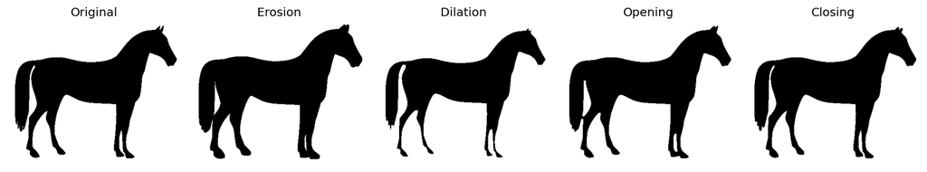

```python
# Demo: morphology on a classic binary mask (horse)
kernel = np.ones((5, 5), np.uint8)

# Erosion removes bright pixels on a dark background
eroded = cv2.erode(horse_u8, kernel, iterations=1)

# Dilation adds bright pixels to a dark background
dilated = cv2.dilate(horse_u8, kernel, iterations=1)

# Opening removes small objects from the foreground
opened = cv2.morphologyEx(horse_u8, cv2.MORPH_OPEN, kernel)

# Closing fills small holes in the foreground
closed = cv2.morphologyEx(horse_u8, cv2.MORPH_CLOSE, kernel)

fig, axes = plt.subplots(1, 5, figsize=(13, 3))
show_gray(axes[0], horse_u8, "Original")
show_gray(axes[1], eroded, "Erosion")
show_gray(axes[2], dilated, "Dilation")
show_gray(axes[3], opened, "Opening")
show_gray(axes[4], closed, "Closing")
plt.tight_layout()
plt.show()
```

# Study Guide

## Quiz 2 Study Guide

**Core topics you should know for the quiz:**

### 1. Noise and filtering choices

- **Gaussian noise**: random additive noise; looks like grain
- **Salt-and-pepper noise**: impulse noise with black/white specks
- **Filter choice**:
  - Gaussian blur reduces Gaussian noise
  - Median filter is best for salt-and-pepper noise
- **Tradeoff**: stronger smoothing removes detail and edges
- **Possible quiz question:** Which filter is best for salt-and-pepper noise, and why?

### 2. Convolution vs correlation

- **Convolution** flips the kernel; **correlation** does not
- Many libraries implement correlation but call it convolution
- **Kernel size** is typically odd (3x3, 5x5)
- **Padding** affects border behavior (reflect, replicate, constant, wrap)
- **Possible quiz question:** What is the difference between convolution and correlation in image filtering?

### 3. Gaussian smoothing

- **Sigma** controls blur strength (bigger sigma -> smoother)
- **Kernel size** should match sigma (larger sigma needs larger kernel)
- Smoothing is often applied **before edge detection**
- **Possible quiz question:** How does increasing sigma change a Gaussian blur’s effect on an image?

### 4. Image derivatives and edges

- **First derivatives**: gradients (Sobel) detect edges and orientation
- **Second derivatives**: Laplacian detects rapid changes (zero crossings)
- **Noise sensitivity**: derivatives amplify noise (Laplacian is very sensitive)
- **Possible quiz question:** Which operator is more noise-sensitive, Sobel or Laplacian, and why?
- **Possible quiz question:** Identify the Sobel $G_x$ filter

### 5. Canny edge detection pipeline

- Steps: **Gaussian blur -> gradient magnitude -> non-max suppression -> hysteresis thresholding**
- Two thresholds (low/high) control edge linking and noise rejection
- **Possible quiz question:** List the main steps of the Canny edge detection pipeline in order.

### 6. Thresholding

- **Global threshold**: one cutoff for the whole image
- **Otsu**: automatic global threshold from histogram
- **Adaptive**: local thresholds for uneven lighting
- Mild smoothing often helps before thresholding
- **Possible quiz question:** When would adaptive thresholding outperform a global threshold?

### 7. Morphology

- **Erosion** shrinks bright regions
- **Dilation** expands bright regions
- **Opening** removes small objects (erosion then dilation)
- **Closing** fills small holes (dilation then erosion)
- Results depend on the **structuring element** size and shape
- **Possible quiz question:** Which morphological operation removes small bright specks while preserving larger objects?

### 8. Sharpening and unsharp masking

- Formula: **I’ = I + alpha * (I - GaussianBlur(I))**
- Large alpha increases sharpness but can amplify noise and halos
- **Possible quiz question:** What does the parameter alpha control in unsharp masking?

### 9. OpenCV pitfalls

- OpenCV uses **BGR** channel order
- Be careful with dtype scaling (uint8 vs float)
- **Possible quiz question:** Why can colors look wrong when displaying an OpenCV image with matplotlib?